# classification_report

**sklearn.metrics.classification_report(*y_true*, *y_pred*, *, *labels=None*, *target_names=None*, *sample_weight=None*, *digits=2*, *output_dict=False*, *zero_division='warn'*)[[source]](https://github.com/scikit-learn/scikit-learn/blob/cc50648cc/sklearn/metrics/_classification.py#L2950)**

Build a text report showing the main classification metrics.

Read more in the User Guide.

**Parameters:**

**y_true**1d array-like, or label indicator array / sparse matrix**

Ground truth (correct) target values. Sparse matrix is only supported when targets are of multilabel type.

**y_pred**1d array-like, or label indicator array / sparse matrix**

Estimated targets as returned by a classifier. Sparse matrix is only supported when targets are of multilabel type.

**labels**array-like of shape (n_labels,), default=None**

Optional list of label indices to include in the report.

**target_names**array-like of shape (n_labels,), default=None**

Optional display names matching the labels (same order).

**sample_weight**array-like of shape (n_samples,), default=None**

Sample weights.

**digits**int, default=2**

Number of digits for formatting output floating point values. When `output_dict` is `True`, this will be ignored and the returned values will not be rounded.

**output_dict**bool, default=False**

If True, return output as dict.

Added in version 0.20.

**zero_division**{“warn”, 0.0, 1.0, np.nan}, default=”warn”**

Sets the value to return when there is a zero division. If set to “warn”, this acts as 0, but warnings are also raised.

Added in version 1.3: `np.nan` option was added.

**Returns:**

**report**str or dict**

Text summary of the precision, recall, F1 score for each class. Dictionary returned if output_dict is True. Dictionary has the following structure:

```
{'label 1': {'precision':0.5,
             'recall':1.0,
             'f1-score':0.67,
             'support':1},
 'label 2': { ... },
  ...
}
```

The reported averages include macro average (averaging the unweighted mean per label), weighted average (averaging the support-weighted mean per label), and sample average (only for multilabel classification). Micro average (averaging the total true positives, false negatives and false positives) is only shown for multi-label or multi-class with a subset of classes, because it corresponds to accuracy otherwise and would be the same for all metrics. See also `precision_recall_fscore_support` for more details on averages.

Note that in binary classification, recall of the positive class is also known as “sensitivity”; recall of the negative class is “specificity”.

See also

**`precision_recall_fscore_support`**

Compute precision, recall, F-measure and support for each class.

**`confusion_matrix`**

Compute confusion matrix to evaluate the accuracy of a classification.

**`multilabel_confusion_matrix`**

Compute a confusion matrix for each class or sample.

#### Examples

```
>>> from sklearn.metrics import classification_report
>>> y_true = [0, 1, 2, 2, 2]
>>> y_pred = [0, 0, 2, 2, 1]
>>> target_names = ['class 0', 'class 1', 'class 2']
>>> print(classification_report(y_true, y_pred, target_names=target_names))
              precision    recall  f1-score   support

     class 0       0.50      1.00      0.67         1
     class 1       0.00      0.00      0.00         1
     class 2       1.00      0.67      0.80         3

    accuracy                           0.60         5
   macro avg       0.50      0.56      0.49         5
weighted avg       0.70      0.60      0.61         5

>>> y_pred = [1, 1, 0]
>>> y_true = [1, 1, 1]
>>> print(classification_report(y_true, y_pred, labels=[1, 2, 3]))
              precision    recall  f1-score   support

           1       1.00      0.67      0.80         3
           2       0.00      0.00      0.00         0
           3       0.00      0.00      0.00         0

   micro avg       1.00      0.67      0.80         3
   macro avg       0.33      0.22      0.27         3
weighted avg       1.00      0.67      0.80         3
```

## Gallery examples

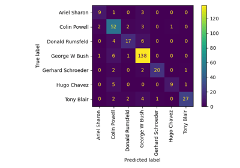

Faces recognition example using eigenfaces and SVMs

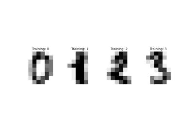

Recognizing hand-written digits

Column Transformer with Heterogeneous Data Sources

Pipeline ANOVA SVM

Custom refit strategy of a grid search with cross-validation

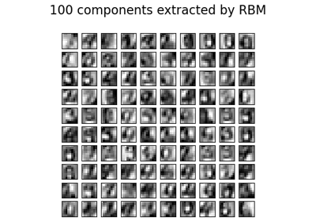

Restricted Boltzmann Machine features for digit classification

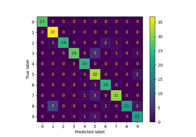

Label Propagation digits: Demonstrating performance

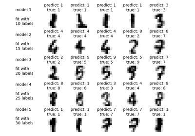

Label Propagation digits: Active learning